# Buzz vs. Bite

### Analysis of ABV and IBU

```
+ More info on Spearman test: https://statistics.laerd.com/statistical-guides/spearmans-rank-order-correlation-statistical-guide.php
```

- Problem: We wish to test if there is a monotonic association between the alochol by volume (ABV) and international bitterness unit (IBU) rating of beers selected from domestic craft breweries.
- Hypotheses:
  - H<sub>o</sub>: $\rho= 0$
  - H<sub>A</sub>: $\rho\neq 0$
- Assumptions:
  - Continuity of data: ✓
  - Paired observations: ✓
  - Data has linear relationship: ✓
  - No significant outliers: ✗
  - Normality: ✗

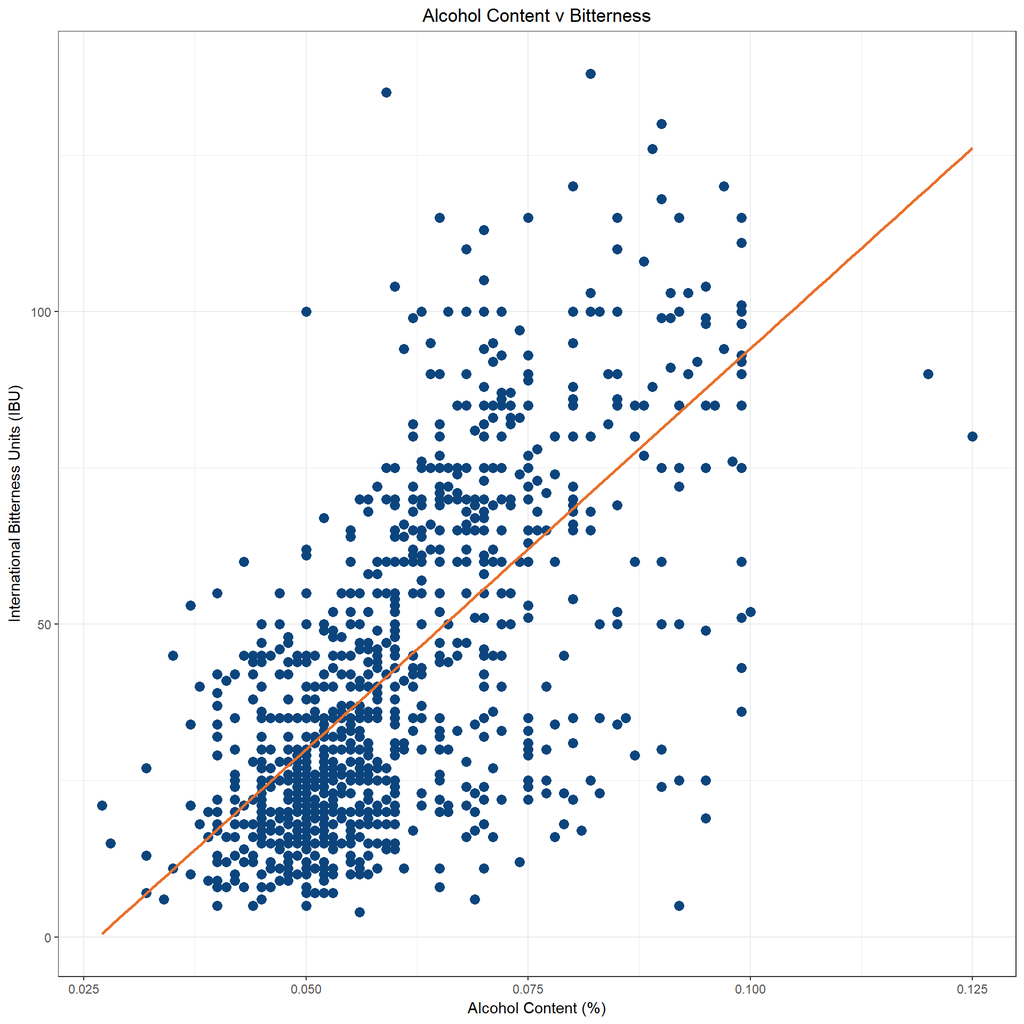

```r
#Scatter plot of ABV v IBU
ggplot(styles, aes(x=abv, y=ibu)) +
  geom_point(color = misc_cool,
             size = 3) +
  geom_smooth(method = "lm",
              se = FALSE,
              color=misc_warm) +
  theme(legend.position="none") +
  ggtitle("Alcohol Content v Bitterness") +
  xlab("Alcohol Content (%)") +
  ylab("International Bitterness Units (IBU)") +
  theme(plot.title = element_text(hjust = 0.5))
```

#### QQ-Plot - Check for Normality

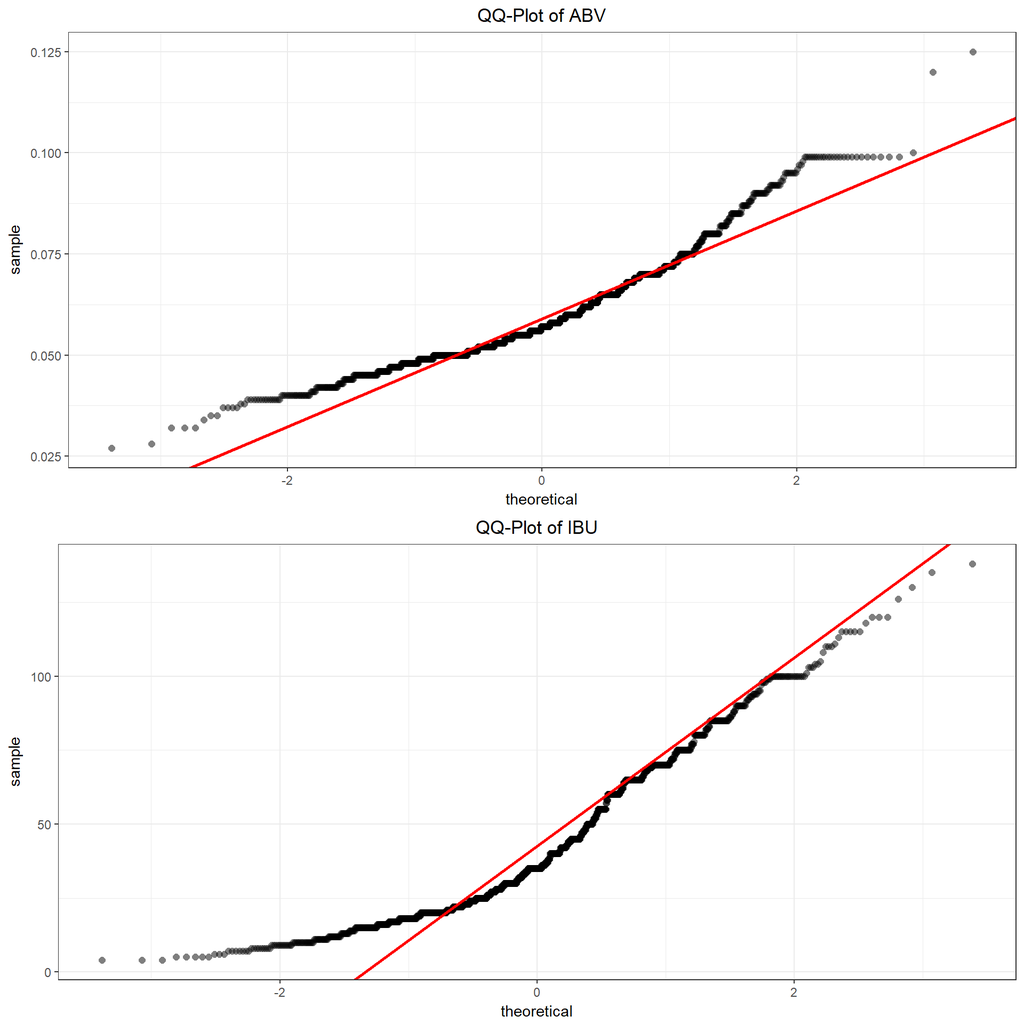

```r
# QQ Plots of IBU and ABV


# calulate line fit
y <- quantile((styles$ibu %>% na.omit()), c(0.25, 0.75))
x <- qnorm(c(0.25, 0.75))
slope <- diff(y)/diff(x)
y_int <- y[1] - slope * x[1]

qq_ibu <- ggplot(styles, aes(sample = styles$ibu)) +
              geom_qq(shape = 16, size = 2, alpha = 0.5) +
              geom_abline(slope = slope, intercept = y_int, colour ='red', size = 1) +
              ggtitle("QQ-Plot of IBU") +
              theme_bw()  +
              theme(plot.title = element_text(hjust = 0.5))


# calulate line fit
y <- quantile((styles$abv %>% na.omit()), c(0.25, 0.75))
x <- qnorm(c(0.25, 0.75))
slope <- diff(y)/diff(x)
y_int <- y[1] - slope * x[1]


qq_abv <- ggplot(styles, aes(sample = styles$abv)) +
            geom_qq(shape = 16, size = 2, alpha = 0.5) +
            geom_abline(slope = slope, intercept = y_int, colour ='red', size = 1) +
            ggtitle("QQ-Plot of ABV") +
            theme_bw() +
            theme(plot.title = element_text(hjust = 0.5))

# plot together
grid.arrange(qq_abv, qq_ibu)
```

#### Histogram - Check for Normality

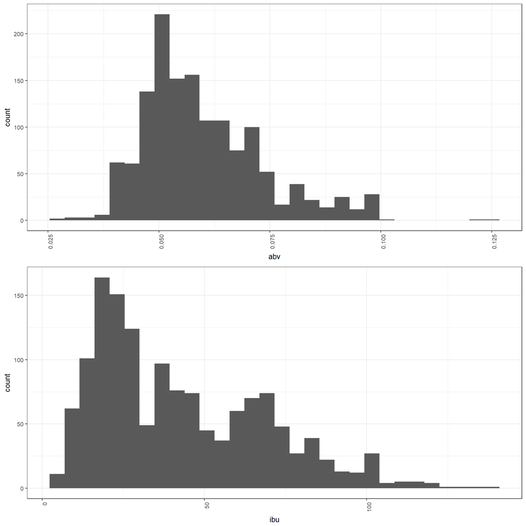

```r
# Histograms of IBU and ABV

hist_ibu <- ggplot(styles %>% na.omit(ibu)) +
              geom_histogram(aes(x=ibu)) +
              theme(text = element_text(size=10),
                  axis.text.x = element_text(angle=90, hjust=1))

hist_abv <- ggplot(styles %>% na.omit(abv)) +
              geom_histogram(aes(x=abv)) +
              theme(text = element_text(size=10),
                  axis.text.x = element_text(angle=90, hjust=1))


# plot together
grid.arrange(hist_abv, hist_ibu)
```

#### Boxplot - Check for Outliers

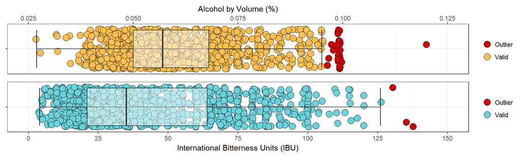

```r
# Boxplots of IBU and ABV


ibu_outliers <- boxplot(styles$ibu, plot = FALSE)[["out"]]

abv_outliers <- boxplot(styles$abv, plot = FALSE)[["out"]]


x<-boxplot(styles$ibu, plot = FALSE)


bp_abv <- ggplot((styles %>% drop_na(abv)), aes(x="", y=abv)) +
      geom_point(aes(fill = ifelse((abv %in% abv_outliers),"Outlier","Valid")),
                 size = 4,
                 shape = 21,
                 position = position_jitter())+
      stat_boxplot(geom ='errorbar') +
      geom_boxplot(alpha=.5,
                   outlier.shape = NA) +
      guides(fill=guide_legend(title= NULL)) +
      xlab(NULL) +
      ylab("Alcohol by Volume (%)") +
      scale_y_continuous(position = "right",
                         breaks = c(.025, .05, .075, .1, .125),
                         limits = c(0.025, .125)) +
      scale_fill_manual(values = c('#cc0606', abv_fill)) +
      theme(plot.title = element_text(hjust = 0.5, size = 22),
            axis.title.y=element_blank()) +
      coord_flip()



bp_ibu <- ggplot((styles %>% drop_na(ibu)), aes(x="", y=ibu)) +
      geom_point(aes(fill = ifelse((ibu %in% ibu_outliers),"Outlier","Valid")),
                 size = 4,
                 shape = 21,
                 position = position_jitter())+
      stat_boxplot(geom ='errorbar') +
      geom_boxplot(alpha = .5,
                   outlier.shape = NA) +
      guides(fill=guide_legend(title= NULL)) +
      xlab(NULL) +
      ylab("International Bitterness Units (IBU)") +
      scale_y_continuous(breaks = c(0, 25, 50, 75, 100, 125, 150),
                         limits = c(0, 150)) +
      scale_fill_manual(values = c('#cc0606', ibu_fill)) +
      theme(plot.title = element_text(hjust = 0.5, size = 22),
            axis.title.y=element_blank()) +
      coord_flip()

# plot together
grid.arrange(bp_abv, bp_ibu)
```

- Due to the lack of normality of the IBU variable and the presence of outliers in both variables, we will use the Spearman Rank-Correlation test as an alternative to the preferred Pearson Correlation.

#### Significance Testing: Spearman Rank-Order Correlation

```
+ More info on Spearman test: https://statistics.laerd.com/statistical-guides/spearmans-rank-order-correlation-statistical-guide.php
```

- Hypotheses:
  - H<sub>o</sub>: $\rho= 0$
  - H<sub>A</sub>: $\rho\neq 0$

```r
alpha <- 0.05

# Significance test
spear_test_result <- cor.test(styles$ibu, styles$abv, method = "spearman", conf.level = alpha, exact=FALSE)

spear_test_result
```

```
##
##  Spearman's rank correlation rho
##
## data:  styles$ibu and styles$abv
## S = 153570000, p-value < 2.2e-16
## alternative hypothesis: true rho is not equal to 0
## sample estimates:
##       rho
## 0.6677798
```

```r
r_sq <- spear_test_result[["estimate"]][["rho"]]^2 # capture r-squared

r_sq
```

```
## [1] 0.4459299
```

## Conclusion

People all around the world have been drinking beef for centuries. Beer has been used for refreshment, for refueling, and even for remittance. A survey of craft brewers in the US shows that beer is still a favorite, mainstream beverage.

We determined that there is a distinct positive correlation between alcohol content and bitterness.

This investigation focused specifically on “craft brewers.” A more complete investigation could be undertaken to include all commercial breweries including brew-pub/micro-brewers as well as large, industrial brewers. Our hypothesis for a more complete investigation would be a “thickening” of the middle of the beer type distribution. That is, big brewers tend to brew the most popular beers whereas craft and micro-brewers can afford to (or choose to) push the boundaries and “live in the tails” of the distribution.

## Appendex

R version 3.5.0 (2018-04-23) Platform: x86_64-w64-mingw32/x64 (64-bit) Running under: Windows 10 x64 (build 16299)

Matrix products: default

locale: [1] LC_COLLATE=English_United States.1252 [2] LC_CTYPE=English_United States.1252  
[3] LC_MONETARY=English_United States.1252 [4] LC_NUMERIC=C  
[5] LC_TIME=English_United States.1252

attached base packages: [1] stats graphics grDevices utils datasets methods base

other attached packages: [1] bindrcpp_0.2.2 gridExtra_2.3 magrittr_1.5  
[4] summarytools_0.8.5 RColorBrewer_1.1-2 maps_3.3.0  
[7] ggplot2_2.2.1 tidyr_0.8.1 dplyr_0.7.5  
[10] knitr_1.20

loaded via a namespace (and not attached): [1] Rcpp_0.12.17 highr_0.7 pillar_1.2.3  
[4] compiler_3.5.0 pryr_0.1.4 plyr_1.8.4  
[7] bindr_0.1.1 bitops_1.0-6 tools_3.5.0  
[10] digest_0.6.15 jsonlite_1.5 lubridate_1.7.4  
[13] evaluate_0.10.1 tibble_1.4.2 gtable_0.2.0  
[16] pkgconfig_2.0.1 rlang_0.2.1 yaml_2.1.19  
[19] stringr_1.3.1 rprojroot_1.3-2 grid_3.5.0  
[22] tidyselect_0.2.4 glue_1.2.0 R6_2.2.2  
[25] rmarkdown_1.10 pander_0.6.1 purrr_0.2.5  
[28] rapportools_1.0 backports_1.1.2 scales_0.5.0  
[31] codetools_0.2-15 htmltools_0.3.6 matrixStats_0.53.1 [34] assertthat_0.2.0 colorspace_1.3-2 labeling_0.3  
[37] stringi_1.1.7 RCurl_1.95-4.10 lazyeval_0.2.1  
[40] munsell_0.5.0

#### Map of Max ABV by State

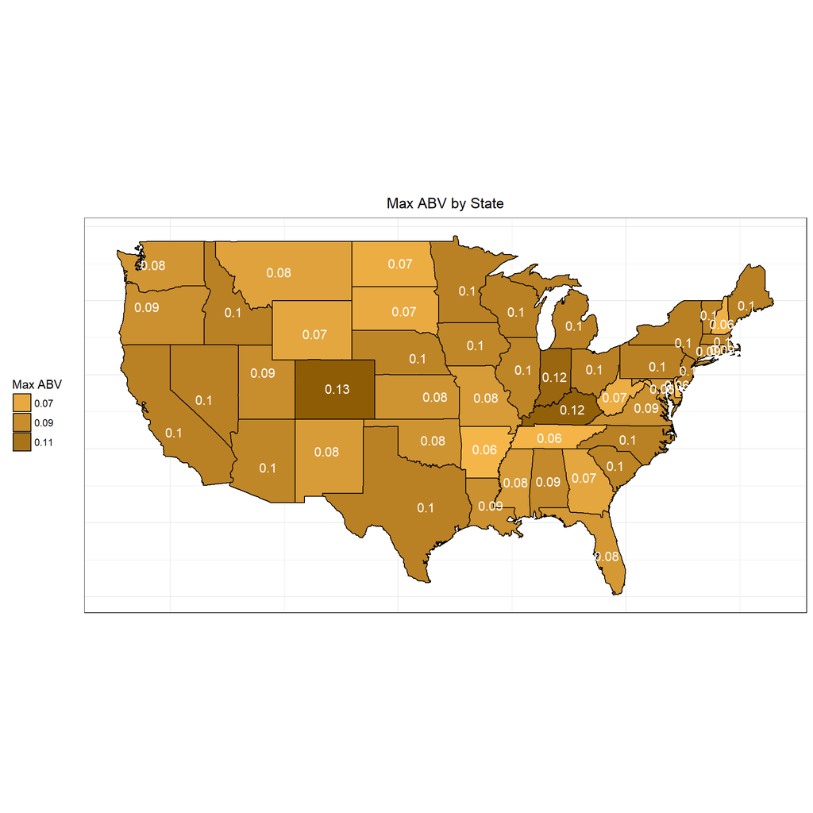

```r
# Map MAX ABV by STATE

x <- select(merged_data, state, abv) %>%
                   na.omit() %>%
                   group_by(state) %>%
                    summarise_all(max) %>%
                   arrange(desc(abv)) %>%
                    left_join(state_ll, by=c("state" = "Abbr"))

breweries_geo2 <- x %>%
                  inner_join(states, by = c("name" = "name"))





ggplot((breweries_geo2 %>% arrange(desc(abv))),
       aes(group = state, stat="identity")) +
  geom_polygon(aes(x = long,
                   y = lat,
                   group=group,
                   fill=abv),
               color = "black") +
  geom_text(data = (x %>%
                    filter(!(state %in% c("AK", "DC", "HI")))), #filter to continental 50 states
            aes(x = lon_center,
                y = lat_center,
                label = as.character(round(abv, 2))),
            color = 'white',
            size = 4
            ) +
  scale_fill_gradient(low=abv_fill, high='#8E5C05') +
  guides(fill=guide_legend(title= "Max ABV")) +
  coord_fixed(1.3) + # fix lat/long display ratio
  ggtitle("Max ABV by State") + # set plot title
  theme(plot.title = element_text(hjust = 0.5)) + # center plot title
  theme(legend.position = "left",
        axis.title.x=element_blank(), # hide x axis title
        axis.text.x=element_blank(),  # hide x axis text
        axis.ticks.x=element_blank(), # hide x axis ticks
        axis.title.y=element_blank(), # hide y axis title
        axis.text.y=element_blank(),  # hide y axis text
        axis.ticks.y=element_blank()) # hide y axis ticks
```

#### Map of Max IBU by State

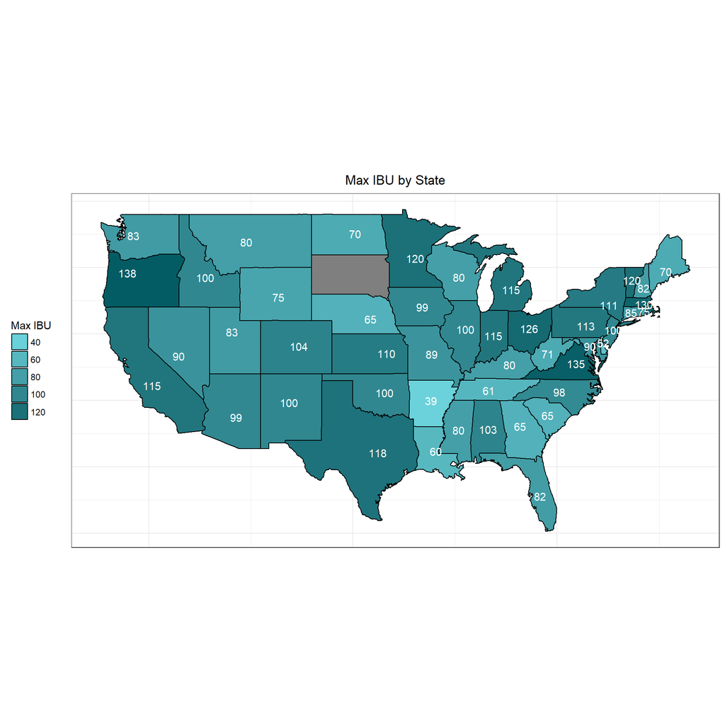

```r
# MAX IBU by STATE

x <- select(merged_data, state, ibu) %>%
                   na.omit() %>%
                   group_by(state) %>%
                    summarise_all(max) %>%
                   arrange(desc(ibu)) %>%
                    full_join(state_ll, by=c("state" = "Abbr"))

breweries_geo2 <- x %>%
                  inner_join(states, by = c("name" = "name"))





ggplot((breweries_geo2 %>% arrange(desc(ibu))),
       aes(group = state, stat="identity")) +
  geom_polygon(aes(x = long,
                   y = lat,
                   group=group,
                   fill=ibu),
               color = "black") +
  geom_text(data = (x %>%
                    filter(!(state %in% c("AK", "DC", "HI")))), #filter to continental 50 states
            aes(x = lon_center,
                y = lat_center,
                label = as.character(ibu)),
            color = 'white'
            ) +
  scale_fill_gradient(low=ibu_fill, high='#035C64') +
  guides(fill=guide_legend(title= "Max IBU")) +
  coord_fixed(1.3) + # fix lat/long display ratio
  ggtitle("Max IBU by State") + # set plot title
  theme(plot.title = element_text(hjust = 0.5)) + # center plot title
  theme(legend.position = "left",
        axis.title.x=element_blank(), # hide x axis title
        axis.text.x=element_blank(),  # hide x axis text
        axis.ticks.x=element_blank(), # hide x axis ticks
        axis.title.y=element_blank(), # hide y axis title
        axis.text.y=element_blank(),  # hide y axis text
        axis.ticks.y=element_blank()) # hide y axis ticks
```